# Assignment 1 Task 1: Sierra Amphibians Data Exploration

Katherine Rosencrance

2023-01-29

# Data and Analysis

These data were collected as a part of The Sierra Lakes Inventory Project (SLIP). This project ran from 1995-2002. Researchers described the physical characteristics of and surveyed aquatic communities for > 8,000 fresh-water water bodies in the southern Sierra Nevada (Knapp et al., 2020). This exploration will visualize data on the mountain yellow-legged frog (*Rana muscosa*).

# Setup

```r
knitr::opts_chunk$set(echo = TRUE, warning = FALSE, message = FALSE)

# Install packages
library(readxl)
library(here)
library(lubridate)
library(tidyverse)
library(cowplot)
```

```r
# Read in the data
amphibians <- read_excel(here("data", "sierra_amphibians.xlsx"))
```

# Data Wrangling Part 1

Wrangle to find the total number of adult, subadult, and tadpole yellow-legged frogs observed in the entire study region by life stage and year.

```r
# filter for life stage and species we need
yellow_amph <- amphibians %>%
  filter (amphibian_life_stage %in% c("Adult", "SubAdult", "Tadpole")) %>%
  filter (amphibian_species == "RAMU") %>%

# make a new column with just the year
  mutate(year = year(survey_date))

# create a summary table to organize by year and life stage
  yellow_amph_table <- yellow_amph %>%
    group_by(year, amphibian_life_stage) %>%
  summarise(count = sum(amphibian_number, na.rm=TRUE))
```

# Create first visualization

Graph the total number of adult, subadult, and tadpole yellow-legged frogs observed in the entire study region by life stage and year.

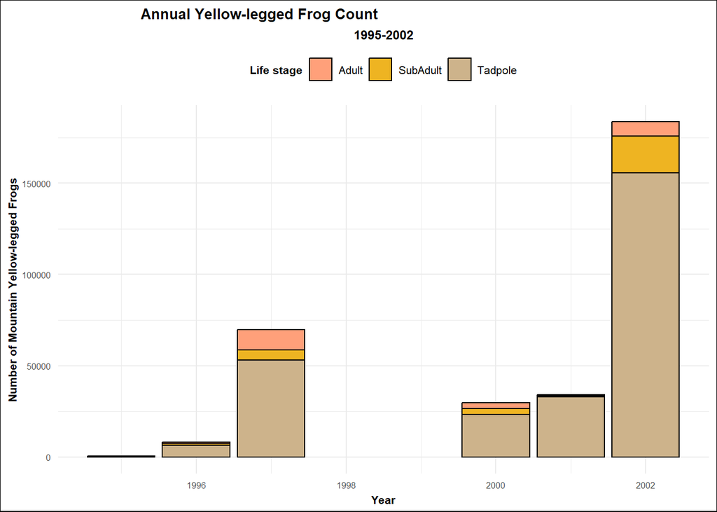

```r
yellow_amph_graph <- ggplot(data = yellow_amph_table, aes(fill = amphibian_life_stage, x = year, y = count)) +
  geom_col(stat = "identity",
           color = "black")+
  scale_fill_manual(values =c("lightsalmon1", "goldenrod2", "navajowhite3"))+
  theme_minimal()+
  labs( x = "Year",
        y = "Number of Mountain Yellow-legged Frogs",
        title = "Annual Yellow-legged Frog Count",
        subtitle = "1995-2002",
        fill = "Life stage")+
  theme(plot.title = element_text(hjust = 0.2, face = "bold", size = 10),
        plot.subtitle = element_text(hjust = 0.5, face = "bold", size = 9),
        axis.title.x = element_text(vjust = 0.2, face = "bold", size = 8),
        axis.title.y = element_text(face = "bold", size = 8),
        plot.background = element_rect(fill = "white"),
        legend.title = element_text(size=8, face = "bold"),
        legend.text = element_text(size=8),
        legend.position = "top",
        axis.text = element_text(size = 6))
yellow_amph_graph
```

# Data Wrangling Part 2

Wrangle to create column graph containing total counts (over all years of the study) of combined adult and subadult endangered mountain yellow-legged frogs observed in the 5 lakes with the greatest total observed counts.

```r
# need to create new df with just adult and subadult (no tadpole)
yellow_amph_sub_adult <- yellow_amph %>%
  filter(amphibian_life_stage %in% c("Adult", "SubAdult"))

# rename the Lake columns to include "Lake"
  yellow_amph_sub_adult$lake_id <- sub("^", "Lake ", yellow_amph_sub_adult$lake_id)

# top 5 lakes
top_5_lakes <- yellow_amph_sub_adult %>%
  group_by(lake_id) %>%
  summarize(count = sum(amphibian_number)) %>%
  slice_max(count, n =5) %>%
  arrange(count)
```

# Create Second Visualization

Create column graph containing total counts (over all years of the study) of combined adult and subadult endangered mountain yellow-legged frogs observed in the 5 lakes with the greatest total observed counts.

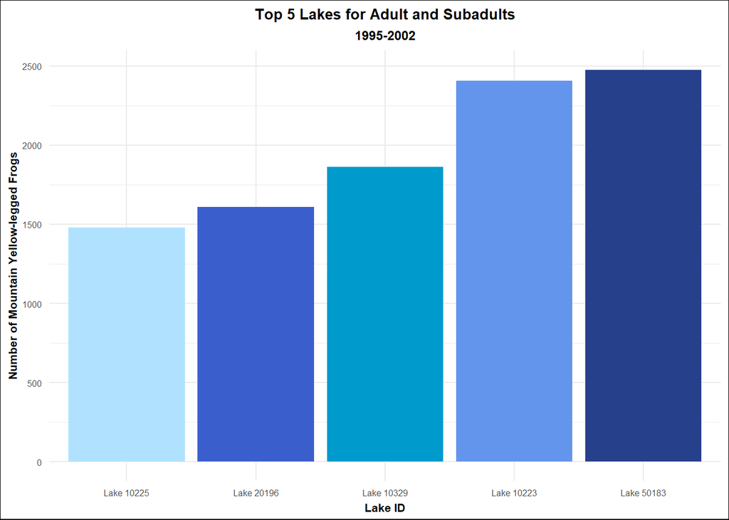

```r
top_lakes_graph <- ggplot(data = top_5_lakes, aes(x = reorder(lake_id, count), y = count)) +
  geom_col(aes(fill = lake_id), show.legend = FALSE)+
  theme_minimal()+
  labs( x = "Lake ID",
        y = "Number of Mountain Yellow-legged Frogs",
        title = "Top 5 Lakes for Adult and Subadults",
        subtitle = "1995-2002")+
  theme(plot.title = element_text(hjust = 0.5, face = "bold", size = 10),
        plot.subtitle = element_text(hjust = 0.5, face = "bold", size = 9),
        axis.title.x = element_text(vjust = 0.2, face = "bold", size = 8),
        axis.title.y = element_text(face = "bold", size = 8),
        axis.text = element_text(size = 6),
        plot.background = element_rect(fill = "white"))+
  scale_fill_manual(values = c("cornflowerblue", "lightskyblue1", "deepskyblue3", "royalblue3", "royalblue4"))

top_lakes_graph
```

# Combine Graphs

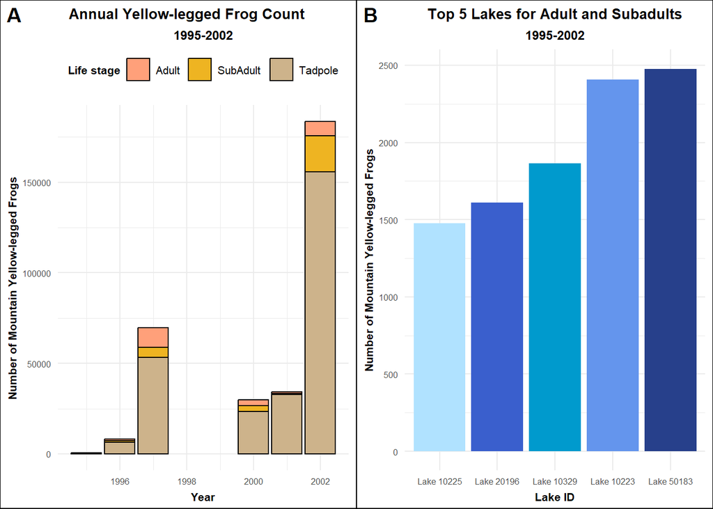

```r
plot_grid(yellow_amph_graph, top_lakes_graph, labels = c('A', 'B'))
```

**Figure 1: Mountain Yellow-Legged Frog Counts.** A. The number of mountain yellow-legged frogs in each year. These counts include tadpoles, subadults, and adults in every lake surveyed from 1995-2002. B. This displays the top 5 lakes with the most adults and subadults surveyed from 1995-2002.

# Citation

**Data Citation:** Knapp, R.A., C. Pavelka, E.E. Hegeman, and T.C. Smith. 2020. The Sierra Lakes Inventory Project: Non-Native fish and community composition of lakes and ponds in the Sierra Nevada, California ver 2. Environmental Data Initiative. https://doi.org/10.6073/pasta/d835832d7fd00d9e4466e44eea87fab3